# HW3

## Task 2 – Linear models on alternative representations of the data

Suppose we are willing to perform a binary classification task to identify if a test time series is from Class 3. a) Train a logistic regression model on the training data and use the model to make a prediction on the test data. Note that you will obtain probabilistic predictions This will require you to select a threshold since 0.5 as a threshold may not work well under this imbalanced class setting. To make things easier, use the ratio of Class 3 instances in the training data as threshold. Use the learned model to predict the class for test data. Present your results in a (2-by-2) confusion matrix.

```r
conc_df_tr1 <- conc_df_tr
conc_df_tr1$class <- as.numeric(conc_df_tr1$class==3)
conc_df_te1 <- conc_df_te
conc_df_te1$class <- as.numeric(conc_df_te$class==3)
thresh <- sum(conc_df_tr1$class)/length(conc_df_tr1$class)

#penalized regression with lambda = 0 and with binomial family is simply logistic regression
set.seed(8)
logist2 <- glmnet(conc_df_tr1[,-1], conc_df_tr1[,1], family = 'binomial', lambda = 0 )
predicted2 <-as.numeric(predict.glmnet(logist2, as.matrix(conc_df_te[,-1])) >= thresh)
actual <- conc_df_te1$class
#Confusion matrix
table(predicted2, actual)
```

```
##           actual
## predicted2    0    1
##          0 2939  179
##          1  189  275
```

```r
#Accuracy of predictions
mean(predicted2==actual)
```

```
## [1] 0.8972641
```

2. An alternative way is to train a logistic regression model with lasso penalties.This will require you setting of penalization term. Use 10-fold cross-validation to determine your ideal lambda level based on binomial deviance. Once you determine your best lambda value using 10-fold cross-validation, perform classification on test data similar to part a and compare your results. Comment on the regression coefficients. Is there any interesting information? Try to interpret the model.

```r
set.seed(9)
cv_res <- cv.glmnet(as.matrix(conc_df_tr1[,-1]), conc_df_tr1[,1], family = 'binomial', nfolds = 10)
logist3 <- glmnet(conc_df_tr1[,-1], conc_df_tr1[,1], family = 'binomial', lambda = cv_res$lambda.min )
predicted3 <-as.numeric(predict.glmnet(logist3, as.matrix(conc_df_te[,-1])) >= thresh)
#Confusion matrix
table(predicted3, actual)
```

```
##           actual
## predicted3    0    1
##          0 3050  127
##          1   78  327
```

```r
#Accuracy of predictions
mean(predicted3==actual)
```

```
## [1] 0.9427694
```

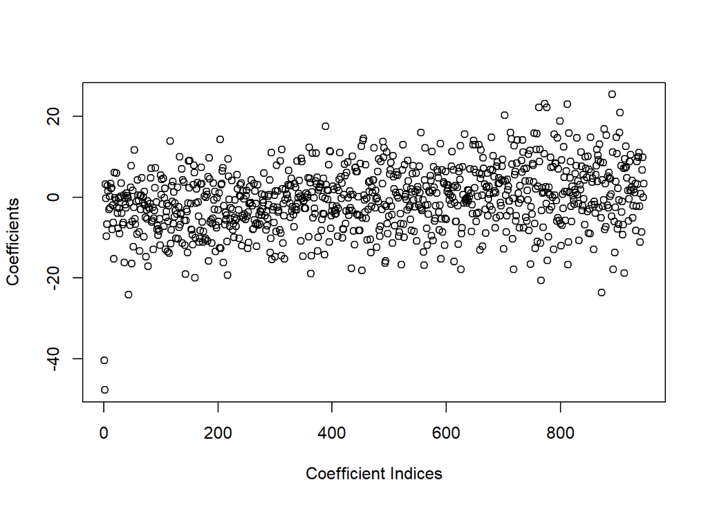

```r
plot(1:length(coefficients(logist2)),(coefficients(logist2)),xlab = "Coefficient Indices", ylab = "Coefficients")
```

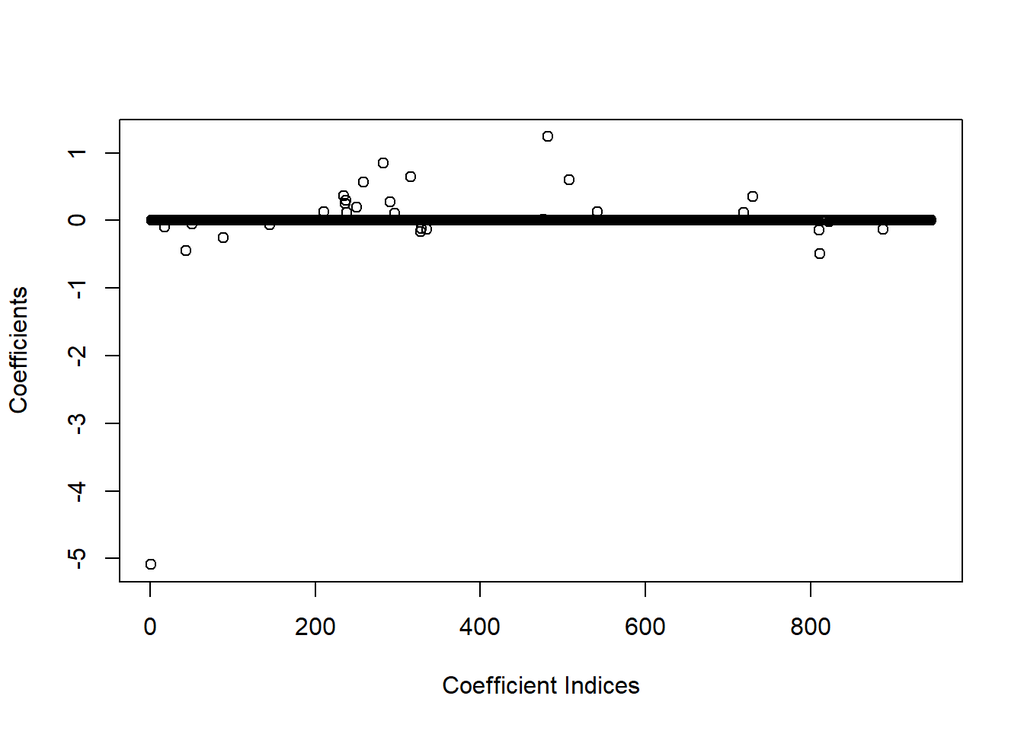

```r
plot(1:length(coefficients(logist3)),(coefficients(logist3)),xlab = "Coefficient Indices", ylab = "Coefficients")
```

```r
#Accuracy of the predictions increased and there are lots of coefficients with values of zero in lasso model compared to logistic regression.
#Moreover most of the significant features are from the x-axis in lasso model. It can be seen from the plot above. Most of the covariates with non-zero
#coefficients are coming from first 315 observations. It makes sense because gesture of Class 3 is a straight which is on the x axis. So it makes sense.
```

3. Given this information, you are expected to transform your training data to distance information (i.e. N by N matrix). Note that you need to perform a similar transformation to your test data. In other words, you need to calculate the distance of each test instance to training instance to obtain a distance based representation for your test data. You can use Euclidean distance as your distance measure. Perform the same training and test strategy as in part b but use the distances as your new feature matrices. Comment on the regression coefficients. What do they imply under this new representation setting?

```r
dist_train <- Distance_for_KNN_test(conc_df_tr1[,-1],conc_df_tr1[,-1])
dist_test <- Distance_for_KNN_test(conc_df_te1[,-1],conc_df_tr1[,-1])
set.seed(10)
cv_res2 <- cv.glmnet(as.matrix(dist_train), conc_df_tr1[,1], family = 'binomial', nfolds = 10)
logist4 <- glmnet(dist_train, conc_df_tr1[,1], family = 'binomial', weights = NULL, offset = NULL, lambda = 0.0035)
predicted4 <-as.numeric(predict.glmnet(logist4, as.matrix(dist_test)) >= thresh)
#Confusion matrix
table(predicted4, actual)
```

```
##           actual
## predicted4    0    1
##          0 3100   83
##          1   28  371
```

```r
#Accuracy of the predictions
mean(predicted4==actual)
```

```
## [1] 0.9690117
```

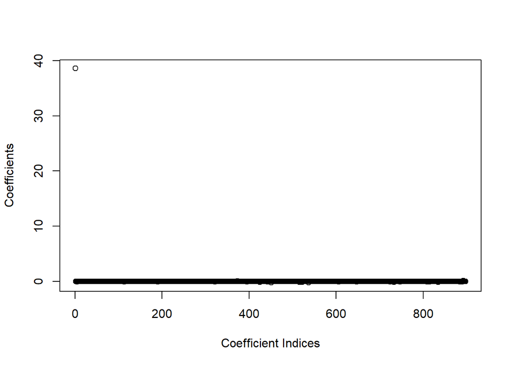

```r
plot(1:length(coefficients(logist4)),(coefficients(logist4)),xlab = "Coefficient Indices", ylab = "Coefficients")
```

```r
#Now, regression coefficients are the scalars of the distances between test instance and training instances.
#As seen from the plot, regression coefficients are very small numbers. Because we use distance information and we have high dimensional data.
#As dimensionality increases, distance information become useless. This model is almost an intercept only model.
#Other than that, model has very high prediction accuracy because we can use nonlinear information.
```

4. Provide an overall comparison on the results you obtain for each part (over all tasks). You can compare test accuracy of each alternative method you developed.